# Лабораторная работа №2

Также открываем файл .bashrc для редактирования.

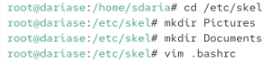

Рисунок 26: Команды cd, mkdir и vim.

Добавляем строку export… в файл в режиме insert.

Далее переходим в уч. запись alice и создаём нового пользователя carol, задаём пароль.

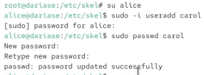

Рисунок 28: Команды su, sudo useradd, passwd.

Далее смотрим информацию о пользователе carol, проверяем, что все все ранее созданные каталоги и внесённые изменения распространяются и на новых пользователей.

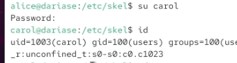

Рисунок 29: Команды su, id. Перешли в уч. запись carol, просмотрели информацию.

Пользователь carol dходит в первоначальную группу users.

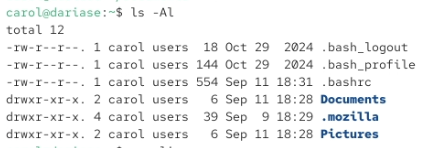

Рисунок 30: Проверяем наличие каталогов Pictures и Documents с помощью команды ls.

Далее переключаемся на пользователя alice, смотрим данные о пароле carol, изменяем их и смотрим ещё раз.

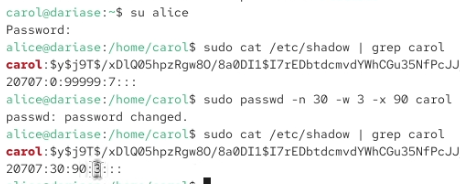

Рисунок 31: Команды cat | grep и passwd, для просмотра и изменения свойств пароля.

Мы изменили свойства срока действия пароля, кол-во дней до предупреждения и кол-во дней использованияя пароля.

Далее проверяем в каких файлах есть идентификаторы alice и carol.

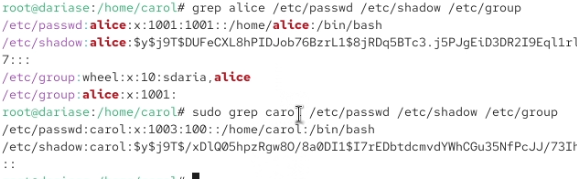

Рисунок 32: Наличие идентификаторов.

4. Работа с группами.

Далее работаем с группами, добавляем новые группы и добавляем в них новых и старых пользователей.

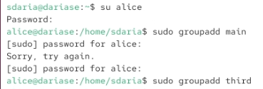

Рисунок 33: Переходим в уч. запись alice, создаём две новые группы с помощью команды groupadd.

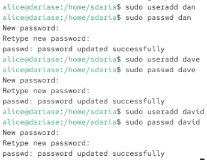

Рисунок 34: Создаём трех новых пользователей и задаем им пароли.

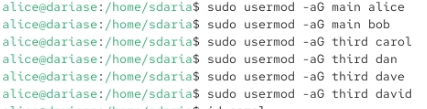

Рисунок 35: Добавляем пользователей в группы.

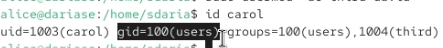

Рисунок 36: Проверяем информацию по пользователю carol.

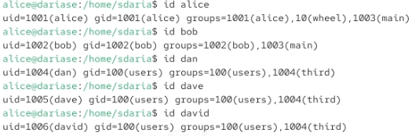

Рисунок 37: Определяем группы пользователей.

Пользователи alice и bob в группе main с идентификатором 1003. Остальные пользователи в группе third с идентификатором 1004.

# Результаты

## Выводы

Я получила представление о работе с учётными записями пользователей и группами пользователей в операционной системе типа Linux.